# Global policy index

Jonas Rekdal Mathisen

20/12/2021

## Background

This analyses utilises the NOURISHING policy database from http://policydatabase.wcrf.org.

The aim is to produce an overview of implemented policies globally within the NOURISHING frameworks pillars:

[figure not shown]

This index provides a simple overview of implemented policies. This simplified index can tell you to what extent a policy dimension is implemented and ongoing in a country only. It does not indicate how broad the policy is, how well it works or how long it has been implemented.

REF FOR SELF: Global policy scan i R:

Lag unike vektorer: 1. Land 2. Policy group (x3 overkategorier) 3. Policy dimension (x10) 4. Sub-policy (x mange)

Sjekke hvilke land har hvilke policyer på sub-policy nivå: • IF-funksjon som sjekker om landet har en policy i det spesifikke område. • Loopen må gå gjennom alle sub-policy områdene for hvert land. • Tilbake vil jeg ha antall policyer som kolonne 1, og en TRUE/FALSE statement i kolonne to om policy>0.

Aggregering [Kan sikkert gjøres i COINr] • I hver sub-policy area må TRUE adderes (T+F+T+T…) • Totalscoren må deretter deles på antall sub-policy områder, innenfor policy dimensjonen • Totalscore multipliseres med 100

Visualisering • Land per rad, sub-policyer i kolonne • Bare checkmarks om policy finnes • 1-100 rate • Eventuelt kart med implementeringsrate

C:/Users/JRMA/AppData/Local/Temp

## Data

Data import and packages utilised.

### Packages

```r
#install.packages("pacman")
#library multiple import
pacman::p_load(countrycode, eurostat, COINr, pheatmap, tidyverse)
```

### Data source

```r
#WCRF policy database
policydb <- read_csv("C:\\Users\\JRMA\\OneDrive - Folkehelseinstituttet\\Dokumenter\\CO-CREATE\\policy-export10-Dec-2021.csv", show_col_types = FALSE)

colnames(policydb) <- c("DB_type", "PolicyArea", "SubPArea", "PolicyAction", "Country", "Topics", "BenchmarkID", "PolicyAreaID", "PolicyDim")

policydb <- policydb[-c(1,6)]

head(policydb)
```

```
## # A tibble: 6 x 7
##   PolicyArea   SubPArea PolicyAction  Country BenchmarkID PolicyAreaID PolicyDim
##   <chr>        <chr>    <chr>         <chr>   <chr>       <chr>        <chr>
## 1 Nutrition l~ Mandato~ "Nutrient co~ Austra~ N1          N            Food env~
## 2 Nutrition l~ Mandato~ "EU nutrient~ Austria N1          N            Food env~
## 3 Nutrition l~ Mandato~ "Nutrient co~ Bahamas N1          N            Food env~
## 4 Nutrition l~ Mandato~ "EU&nbsp;nut~ Belgium N1          N            Food env~
## 5 Nutrition l~ Mandato~ "EU nutrient~ Bulgar~ N1          N            Food env~
## 6 Nutrition l~ Mandato~ "Nutrient co~ Canada  N1          N            Food env~
```

```r
countries <- distinct(policydb, Country)

##Blank dataframe with PolicyArena and SubPolicyArena
cleanFrame <- policydb %>% select("PolicyArea", "SubPArea") %>% distinct_all()
cleanFrame
```

```
## # A tibble: 67 x 2
##    PolicyArea                              SubPArea
##    <chr>                                   <chr>
##  1 Nutrition label standards and regulati~ "Mandatory nutrient lists on package~
##  2 Nutrition label standards and regulati~ "Trans fats included in mandatory nu~
##  3 Nutrition label standards and regulati~ "Clearly visible \"interpretative\" ~
##  4 Nutrition label standards and regulati~ "On-shelf labelling"
##  5 Nutrition label standards and regulati~ "Calorie and nutrient labelling on m~
##  6 Nutrition label standards and regulati~ "Warning labels on menus and display~
##  7 Nutrition label standards and regulati~ "Rules on nutrient claims (ie nutrie~
##  8 Nutrition label standards and regulati~ "Rules on health claims (ie nutrient~
##  9 Offer healthy food and set standards i~ "Fruit & vegetable initiatives in sc~
## 10 Offer healthy food and set standards i~ "Mandatory standards for food availa~
## # ... with 57 more rows
```

```r
###Vectorisation

#(DIMENSION NAME + DIMCODE) + PolicyAreaNAME + PACODE + SubPolicyNAME + SPACODE

#Policy Areas
# PAreas <- policydb %>% select("PolicyAreaID") %>% distinct(PolicyAreaID)
AggHiearchy <- policydb %>% distinct(SubPArea, BenchmarkID, PolicyArea, PolicyAreaID)

PAreas <- policydb %>% distinct(PolicyArea, PolicyAreaID) #List of PAreas

vector_PAr <- c(t(PAreas))

short_v_PAr <- c("N", "O", "U", "R", "I", "S", "H", "I2", "N2", "G")

KEY_PAletter <- cbind(vector_PAr, short_v_PAr)
KEY_PAletter <- as.data.frame(KEY_PAletter)
colnames(KEY_PAletter) <- c("PolicyArea", "PA_short")
KEY_PAletter
```

```
##                                                                                   PolicyArea
## 1  Nutrition label standards and regulations on the use of claims and implied claims on food
## 2                                                                                          N
## 3    Offer healthy food and set standards in public institutions and other specific settings
## 4                                                                                          O
## 5                   Use economic tools to address food affordability and purchase incentives
## 6                                                                                          U
## 7                          Restrict food advertising and other forms of commercial promotion
## 8                                                                                          R
## 9                                       Improve nutritional quality of the whole food supply
## 10                                                                                         I
## 11          Set incentives and rules to create a healthy retail and food service environment
## 12                                                                                         S
## 13           Harness supply chain and actions across sectors to ensure coherence with health
## 14                                                                                         H
```

[output cut: 27 more lines]

```r
#Sub-policy areas
SubPas <- policydb %>% distinct(SubPArea, BenchmarkID)
vector_SubPas <- c(t(SubPas$BenchmarkID))

SubPas
```

```
## # A tibble: 67 x 2
##    SubPArea                                                          BenchmarkID
##    <chr>                                                             <chr>
##  1 "Mandatory nutrient lists on packaged food*"                      N1
##  2 "Trans fats included in mandatory nutrient labels"                N2
##  3 "Clearly visible \"interpretative\" labels and warning labels"    N3
##  4 "On-shelf labelling"                                              N4
##  5 "Calorie and nutrient labelling on menus and displays in out-of-~ N5
##  6 "Warning labels on menus and displays in out-of-home venues"      N6
##  7 "Rules on nutrient claims (ie nutrient content and nutrient comp~ N7
##  8 "Rules on health claims (ie nutrient function and disease risk r~ N8
##  9 "Fruit & vegetable initiatives in schools"                        O1
## 10 "Mandatory standards for food available in schools including res~ O2
## # ... with 57 more rows
```

```r
#as.list kunne funket

#PolicyDims
PolicyDims <- policydb %>% distinct(PolicyDim,PolicyAreaID)
```

The `policies` data consists of 899 policy actions.

#### Policy actions per country

These actions are located in 137 different countries. The number of policies identified in each country is listed below:

```r
PA_countries <- policydb %>% count(Country, sort=TRUE, name = "Number of policy actions")

PA_countries
```

```
## # A tibble: 137 x 2
##    Country     `Number of policy actions`
##    <chr>                            <int>
##  1 UK                                  66
##  2 USA                                 50
##  3 Norway                              33
##  4 Portugal                            33
##  5 Malaysia                            23
##  6 Netherlands                         22
##  7 Poland                              21
##  8 Australia                           20
##  9 Germany                             20
## 10 Spain                               20
## # ... with 127 more rows
```

```r
count
```

[output not shown]

#### A hiearchical overview: Country -> Policy Area -> Sub- Policy area

```r
country_hierch <- policydb %>% count(Country, PolicyArea, SubPArea) #Text

####OR

country_hierch2 <- policydb %>% count(Country, PolicyAreaID, BenchmarkID) #IDs



country_hierch
```

```
## # A tibble: 800 x 4
##    Country             PolicyArea                 SubPArea                     n
##    <chr>               <chr>                      <chr>                    <int>
##  1 Afghanistan         Inform people about food ~ Development and communi~     1
##  2 Albania             Inform people about food ~ Development and communi~     1
##  3 American Samoa      Harness supply chain and ~ Governance structures f~     1
##  4 Antigua and Barbuda Harness supply chain and ~ Governance structures f~     1
##  5 Antigua and Barbuda Inform people about food ~ Development and communi~     1
##  6 Antigua and Barbuda Inform people about food ~ Public awareness, mass ~     1
##  7 Argentina           Improve nutritional quali~ Mandatory limits on lev~     1
##  8 Argentina           Improve nutritional quali~ Mandatory removal of tr~     1
##  9 Argentina           Improve nutritional quali~ Voluntary reformulation~     1
## 10 Argentina           Inform people about food ~ Development and communi~     1
## # ... with 790 more rows
```

#### Policy hierarchy

```r
#filter(Country=="Norway") Lage en funksjon som tester alle land opp mot hverandre og hiearkiene? Hvor er man like etc?

PA_hierch <- policydb %>% count(PolicyArea, SubPArea, sort=TRUE, name = "Number of policy actions")

PA_hierch
```

```
## # A tibble: 67 x 3
##    PolicyArea                    SubPArea                     `Number of policy~
##    <chr>                         <chr>                                     <int>
##  1 Inform people about food and~ Development and communicati~                 88
##  2 Nutrition label standards an~ Mandatory nutrient lists on~                 62
##  3 Use economic tools to addres~ Health-related food taxes                    50
##  4 Offer healthy food and set s~ Mandatory standards for foo~                 48
##  5 Improve nutritional quality ~ Voluntary reformulation of ~                 44
##  6 Nutrition label standards an~ Rules on nutrient claims (i~                 44
##  7 Nutrition label standards an~ Rules on health claims (ie ~                 39
##  8 Inform people about food and~ Public awareness, mass medi~                 37
##  9 Offer healthy food and set s~ Standards in other specific~                 35
## 10 Harness supply chain and act~ Governance structures for m~                 34
## # ... with 57 more rows
```

#### Policy areas

```r
PA_dimensions <- policydb %>% count(PolicyArea, sort=TRUE, name = "Number of policy actions")
PA_dimensions
```

```
## # A tibble: 10 x 2
##    PolicyArea                                             `Number of policy act~
##    <chr>                                                                   <int>
##  1 Nutrition label standards and regulations on the use ~                    200
##  2 Inform people about food and nutrition through public~                    164
##  3 Offer healthy food and set standards in public instit~                    147
##  4 Improve nutritional quality of the whole food supply                       87
##  5 Use economic tools to address food affordability and ~                     66
##  6 Give nutrition education and skills                                        63
##  7 Restrict food advertising and other forms of commerci~                     62
##  8 Harness supply chain and actions across sectors to en~                     54
##  9 Nutrition advice and counselling in healthcare settin~                     35
## 10 Set incentives and rules to create a healthy retail a~                     21
```

### Sub-policy areas

```r
PA_SPA <- policydb %>% count(PolicyArea, SubPArea, sort=TRUE, name = "Number of policy actions")

PA_SPA
```

```
## # A tibble: 67 x 3
##    PolicyArea                    SubPArea                     `Number of policy~
##    <chr>                         <chr>                                     <int>
##  1 Inform people about food and~ Development and communicati~                 88
##  2 Nutrition label standards an~ Mandatory nutrient lists on~                 62
##  3 Use economic tools to addres~ Health-related food taxes                    50
##  4 Offer healthy food and set s~ Mandatory standards for foo~                 48
##  5 Improve nutritional quality ~ Voluntary reformulation of ~                 44
##  6 Nutrition label standards an~ Rules on nutrient claims (i~                 44
##  7 Nutrition label standards an~ Rules on health claims (ie ~                 39
##  8 Inform people about food and~ Public awareness, mass medi~                 37
##  9 Offer healthy food and set s~ Standards in other specific~                 35
## 10 Harness supply chain and act~ Governance structures for m~                 34
## # ... with 57 more rows
```

## Methods

### Make empty index

```r
PAreas <- policydb %>% distinct(PolicyArea, PolicyAreaID) #List of PAreas



vector_PAr <- c(t(PAreas)) #Make into character strings and list

short_v_PAr <- c("N", "O", "U", "R", "I", "S", "H", "I2", "N2", "G")

countrylist <- c(t(countries))

GI_blank <- countries

GI_blank[ , c(short_v_PAr)] <- NA #eller short_V_PAr

GI_blank
```

```
## # A tibble: 137 x 11
##    Country    N     O     U     R     I     S     H     I2    N2    G
##    <chr>      <lgl> <lgl> <lgl> <lgl> <lgl> <lgl> <lgl> <lgl> <lgl> <lgl>
##  1 Australia  NA    NA    NA    NA    NA    NA    NA    NA    NA    NA
##  2 Austria    NA    NA    NA    NA    NA    NA    NA    NA    NA    NA
##  3 Bahamas    NA    NA    NA    NA    NA    NA    NA    NA    NA    NA
##  4 Belgium    NA    NA    NA    NA    NA    NA    NA    NA    NA    NA
##  5 Bulgaria   NA    NA    NA    NA    NA    NA    NA    NA    NA    NA
##  6 Canada     NA    NA    NA    NA    NA    NA    NA    NA    NA    NA
##  7 Chile      NA    NA    NA    NA    NA    NA    NA    NA    NA    NA
##  8 China      NA    NA    NA    NA    NA    NA    NA    NA    NA    NA
##  9 Colombia   NA    NA    NA    NA    NA    NA    NA    NA    NA    NA
## 10 Costa Rica NA    NA    NA    NA    NA    NA    NA    NA    NA    NA
## # ... with 127 more rows
```

### Fill table with true or false

```r
#country_hierch

#Country > PArea > SubPA > Count

truef <- country_hierch %>% mutate(
  PolicyActionImplemented = if_else(n > 0, TRUE, FALSE, missing=FALSE)
)

PA_level_TF <- truef %>%
  select("Country", "PolicyArea","PolicyActionImplemented") %>%
  right_join(KEY_PAletter, "PolicyArea") %>%
  select(c("Country", "PA_short")) %>% distinct() %>%
  pivot_wider(names_from = "PA_short", values_from = "PA_short") %>%
  mutate(
    across(c("N", "O", "U", "R", "I", "S", "H", "I2", "N2", "G"),
           ~if_else(!is.na(.), 1, 0)
           )
    )

PA_level_TF
```

```
## # A tibble: 137 x 11
##    Country               I     U    N2     N     H     O     R     S    I2     G
##    <chr>             <dbl> <dbl> <dbl> <dbl> <dbl> <dbl> <dbl> <dbl> <dbl> <dbl>
##  1 Afghanistan           1     0     0     0     0     0     0     0     0     0
##  2 Albania               1     0     0     0     0     0     0     0     0     0
##  3 American Samoa        0     1     0     0     0     0     0     0     0     0
##  4 Antigua and Barb~     1     1     0     0     0     0     0     0     0     0
##  5 Argentina             1     0     1     1     0     0     0     0     0     0
##  6 Australia             1     1     1     1     1     0     0     0     0     0
##  7 Austria               1     1     1     1     0     0     0     0     0     0
##  8 Bahamas               1     1     0     1     0     0     0     0     0     0
##  9 Bahrain               1     1     0     1     0     0     0     0     0     0
## 10 Bangladesh            1     0     0     0     0     0     0     0     0     0
## # ... with 127 more rows
```

```r
#Add new column to DF with raw score

PA_level_TF_calc <- PA_level_TF %>% mutate(rawScore = rowSums(across(c("N", "O", "U", "R", "I", "S", "H", "I2", "N2", "G"))))

#Add new column with normalised score

PA_level_TF_calc <- PA_level_TF_calc %>% mutate(TotalScore = rawScore/length(short_v_PAr)*100)
```

The above shows the score for the overall policy areas and would be the simplest form of overview. This can be further nuanced by utilising data on subpolicy area level:

```r
country_hierch2
```

```
## # A tibble: 800 x 4
##    Country             PolicyAreaID BenchmarkID     n
##    <chr>               <chr>        <chr>       <int>
##  1 Afghanistan         I(2)         I(2)1           1
##  2 Albania             I(2)         I(2)1           1
##  3 American Samoa      H            H7              1
##  4 Antigua and Barbuda H            H7              1
##  5 Antigua and Barbuda I(2)         I(2)1           1
##  6 Antigua and Barbuda I(2)         I(2)3           1
##  7 Argentina           I            I1              1
##  8 Argentina           I            I3              1
##  9 Argentina           I            I4              1
## 10 Argentina           I(2)         I(2)1           1
## # ... with 790 more rows
```

```r
#Country > PArea > SubPA > Count

truef_spa <- country_hierch2 %>% mutate(
  PolicyActionImplemented = if_else(n > 0, TRUE, FALSE, missing=FALSE)
)

SPA_level_TF <- truef_spa %>%
  select("Country", "BenchmarkID","PolicyActionImplemented") %>%
  select(c("Country", "BenchmarkID")) %>% distinct() %>%
  pivot_wider(names_from = "BenchmarkID", values_from = "BenchmarkID") %>%
  ungroup() %>%
  mutate(
    across(.cols = -Country,
           ~if_else(!is.na(.), 1, 0)
    )
  )


#Add new column to DF with raw score

PA_level_TF_calc <- PA_level_TF %>% mutate(rawScore = rowSums(across(c("N", "O", "U", "R", "I", "S", "H", "I2", "N2", "G"))))

#Add new column with normalised score

PA_level_TF_calc <- PA_level_TF_calc %>% mutate(TotalScore = rawScore/length(short_v_PAr)*100)
```

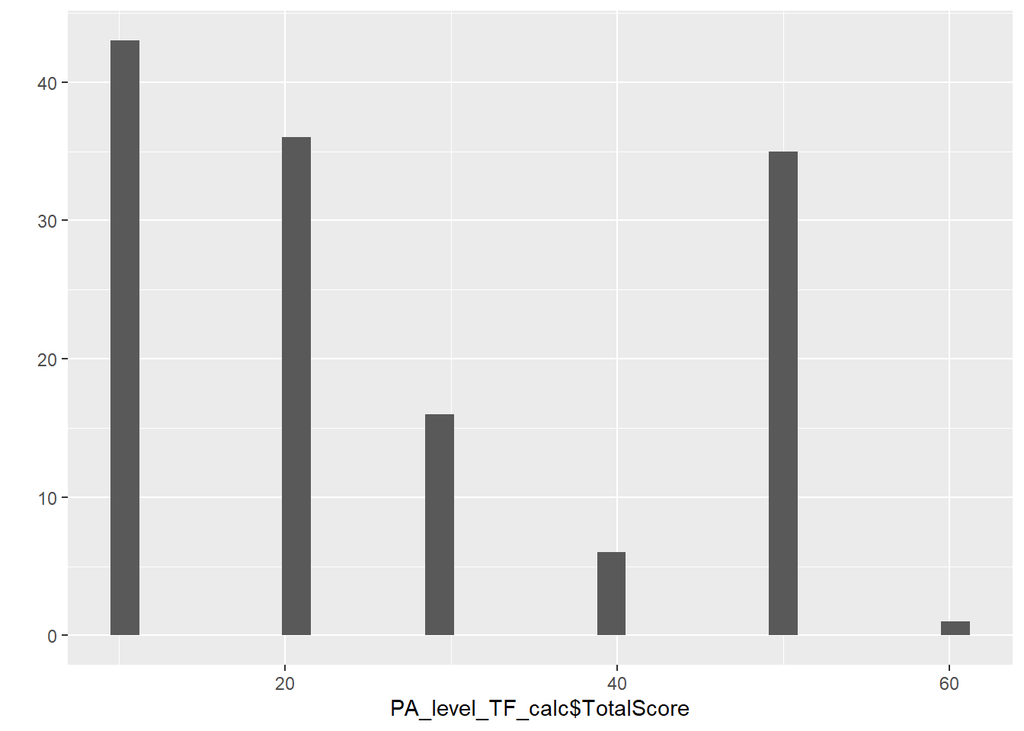

```r
#Plot results
qplot(PA_level_TF_calc$TotalScore, geom="histogram")
```

```r
DescStats <- PA_level_TF_calc %>% select("TotalScore") %>% summary()
StandardDeviation <- sd(PA_level_TF_calc$TotalScore)


summary <- list(DescStats, StandardDeviation)

summary
```

```
## [[1]]
##    TotalScore
##  Min.   :10.00
##  1st Qu.:10.00
##  Median :20.00
##  Mean   :26.86
##  3rd Qu.:50.00
##  Max.   :60.00
##
## [[2]]
## [1] 16.03084
```

```r
corellSPA <- SPA_level_TF %>% select(-Country) %>% cor()
corellPA <- PA_level_TF %>% select(-Country) %>% cor()

corellPA
```

```
##              I           U         N2           N           H           O
## I   1.00000000  0.06575893 0.02326199  0.02879248  0.19055110 -0.17307925
## U   0.06575893  1.00000000 0.28553018  0.27384587  0.46685722 -0.10158699
## N2  0.02326199  0.28553018 1.00000000  0.52421804  0.66000532  0.09859431
## N   0.02879248  0.27384587 0.52421804  1.00000000  0.54107002 -0.09431165
## H   0.19055110  0.46685722 0.66000532  0.54107002  1.00000000 -0.05409409
## O  -0.17307925 -0.10158699 0.09859431 -0.09431165 -0.05409409  1.00000000
## R  -0.17307925 -0.10158699 0.09859431 -0.09431165 -0.05409409  1.00000000
## S  -0.17307925 -0.10158699 0.09859431 -0.09431165 -0.05409409  1.00000000
## I2 -0.17307925 -0.10158699 0.09859431 -0.09431165 -0.05409409  1.00000000
## G  -0.17307925 -0.10158699 0.09859431 -0.09431165 -0.05409409  1.00000000
##              R           S          I2           G
## I  -0.17307925 -0.17307925 -0.17307925 -0.17307925
## U  -0.10158699 -0.10158699 -0.10158699 -0.10158699
## N2  0.09859431  0.09859431  0.09859431  0.09859431
## N  -0.09431165 -0.09431165 -0.09431165 -0.09431165
## H  -0.05409409 -0.05409409 -0.05409409 -0.05409409
## O   1.00000000  1.00000000  1.00000000  1.00000000
## R   1.00000000  1.00000000  1.00000000  1.00000000
## S   1.00000000  1.00000000  1.00000000  1.00000000
## I2  1.00000000  1.00000000  1.00000000  1.00000000
## G   1.00000000  1.00000000  1.00000000  1.00000000
```

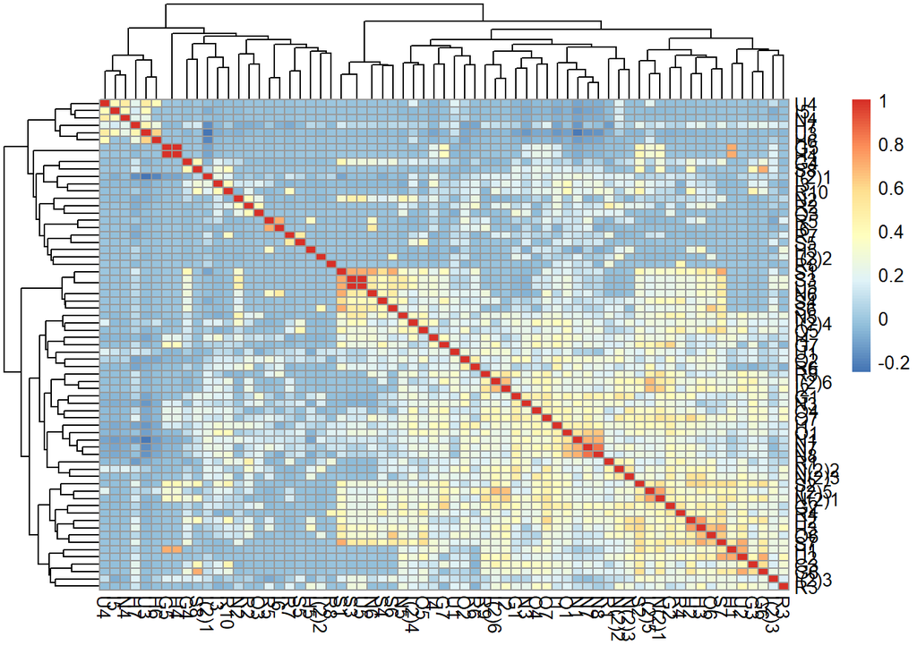

```r
corellzSPA <- pheatmap(corellSPA)
```

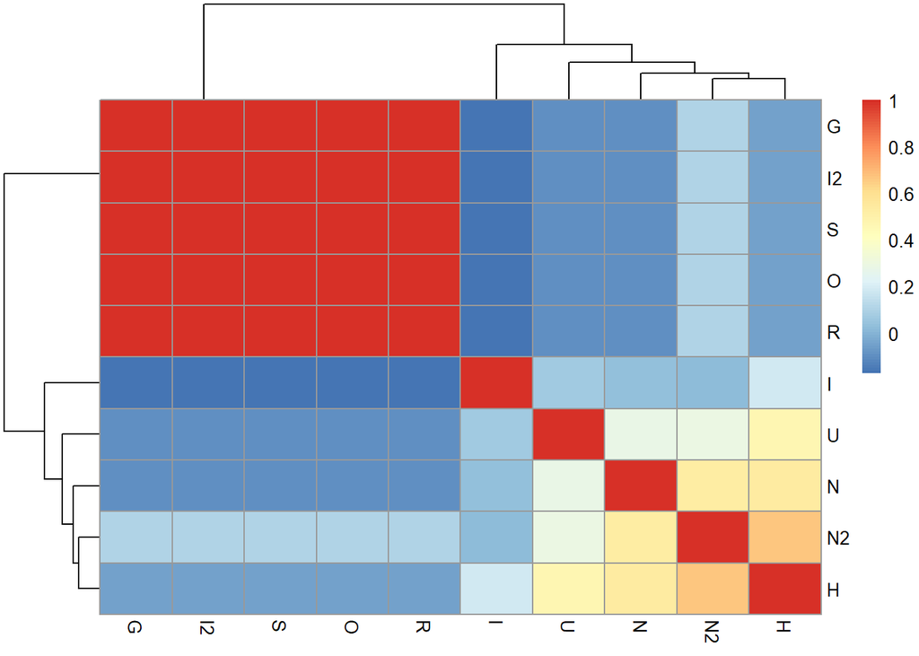

```r
corellzPA <- pheatmap(corellPA)
```

```r
save_pheatmap_pdf <- function(x, filename, width=10, height=7) {
   stopifnot(!missing(x))
   stopifnot(!missing(filename))
   pdf(filename, width=width, height=height)
   grid::grid.newpage()
   grid::grid.draw(x$gtable)
   dev.off()
}

save_pheatmap_pdf(corellzPA, "test.pdf")
```

```r
#Liste NOURISHING letter:
KEY_PAletter
```

```
##                                                                                   PolicyArea
## 1  Nutrition label standards and regulations on the use of claims and implied claims on food
## 2                                                                                          N
## 3    Offer healthy food and set standards in public institutions and other specific settings
## 4                                                                                          O
## 5                   Use economic tools to address food affordability and purchase incentives
## 6                                                                                          U
## 7                          Restrict food advertising and other forms of commercial promotion
## 8                                                                                          R
## 9                                       Improve nutritional quality of the whole food supply
## 10                                                                                         I
## 11          Set incentives and rules to create a healthy retail and food service environment
## 12                                                                                         S
## 13           Harness supply chain and actions across sectors to ensure coherence with health
## 14                                                                                         H
```

[output cut: 27 more lines]

```r
#Liste land
countrylist
```

```
##   [1] "Australia"                     "Austria"
##   [3] "Bahamas"                       "Belgium"
##   [5] "Bulgaria"                      "Canada"
##   [7] "Chile"                         "China"
##   [9] "Colombia"                      "Costa Rica"
##  [11] "Croatia"                       "Cyprus"
##  [13] "Czech Republic"                "Denmark"
##  [15] "Ecuador"                       "El Salvador"
##  [17] "Estonia"                       "Finland"
##  [19] "France"                        "Germany"
##  [21] "Greece"                        "Guatemala"
##  [23] "Gulf Cooperation Council"      "Honduras"
##  [25] "Hong Kong"                     "Hungary"
##  [27] "Iceland"                       "India"
##  [29] "Indonesia"                     "Ireland"
```

[output cut: 54 more lines]

```r
#Funksjon som sjekker om land har N-letter TRUE, hent så til GI_index (TRUE) else=FALSE.
GI <- GI_blank

      #N må være en funksjon i liste
#GI <- N = case_when(country %is%in% countrylist &)
```

### Vectorisation

lvl1 <- “NOURISHING” lvl2 <- c(“Food environment”, “Food system”, “Behaviour change communication”) lvl3 <- c("")

```r
##Load raw files from GlobalPolIndex


## Indicator data
COINr_SPA <- SPA_level_TF

names(COINr_SPA)[names(COINr_SPA) == "Country"] <- "UnitName"


COINr_SPA <- COINr_SPA %>% mutate(UnitCode = countrycode(sourcevar = UnitName, origin="country.name", destination="iso3c"))
#Some values are missing: Gulf Cooperation Council, Micronesia, Romania, Wallis and Futuna

Missing <- COINr_SPA %>% subset(is.na(UnitCode)) %>% select(UnitName, UnitCode)

#For this exercise these are dropped
COINr_SPA <- na.omit(COINr_SPA)

isCoCREATE <- c("NOR", "NLD", "PRT", "POL", "GBR")

#Continue adding groups for countries
COINr_SPA <- COINr_SPA %>% mutate(
  Group_Continent = countrycode(sourcevar = UnitName, origin="country.name", destination="continent"),
  Group_EU28 = countrycode(sourcevar = UnitName, origin="country.name", destination="eu28"),
  Group_Region = countrycode(sourcevar = UnitName, origin="country.name", destination="region"),
  Group_COCREATE = case_when(UnitCode %in% unlist(isCoCREATE) ~ TRUE, TRUE ~ FALSE))
#Consider adding certain variables etc for further analysis (eurostat stuff)



IndData <- COINr_SPA

IndData <- IndData %>% mutate_if(is_double,as.integer)

IndData
```

```
## # A tibble: 133 x 73
##    UnitName    `I(2)1`    H7 `I(2)3`    I1    I3    I4 `I(2)4`    N2    G1    G2
##    <chr>         <int> <int>   <int> <int> <int> <int>   <int> <int> <int> <int>
##  1 Afghanistan       1     0       0     0     0     0       0     0     0     0
##  2 Albania           1     0       0     0     0     0       0     0     0     0
##  3 American S~       0     1       0     0     0     0       0     0     0     0
##  4 Antigua an~       1     1       1     0     0     0       0     0     0     0
##  5 Argentina         1     0       0     1     1     1       1     1     0     0
##  6 Australia         1     0       1     1     0     0       1     0     1     1
##  7 Austria           1     0       0     1     0     1       0     0     0     1
##  8 Bahamas           1     1       1     0     0     0       0     0     0     0
##  9 Bahrain           0     0       0     0     0     0       0     0     0     0
## 10 Bangladesh        1     0       0     0     0     0       0     0     0     0
## # ... with 123 more rows, and 62 more variables: N1 <int>, N3 <int>, N5 <int>,
## #   N7 <int>, N8 <int>, O1 <int>, O2 <int>, O4 <int>, O5 <int>, O7 <int>,
## #   R4 <int>, G7 <int>, S4 <int>, U1 <int>, G3 <int>, I(2)6 <int>, R10 <int>,
## #   S2 <int>, G4 <int>, O6 <int>, H2 <int>, H3 <int>, H5 <int>, N(2)2 <int>,
## #   N(2)3 <int>, R3 <int>, R5 <int>, S3 <int>, U5 <int>, R1 <int>, R2 <int>,
## #   R6 <int>, I(2)2 <int>, U3 <int>, O3 <int>, R9 <int>, I(2)5 <int>, I5 <int>,
## #   N4 <int>, U4 <int>, R7 <int>, S5 <int>, R8 <int>, I6 <int>, N6 <int>, ...
```